# List, Loops, and Data frame (W4)

2019-10-03

## list

- vector 是 R 裡面最「簡單」的資料結構。有時候我們需要比較更複雜的資料結構處理我們遇到的資料，例如，我們或許需要儲存**不同資料類型**或是**具有階層結構**的資料。面對這兩種需求，vector 無能為力，因此需要用到 R 的 list。
- R 可以透過 `list()` 去製造出 list。`list()` 的使用方式很類似用來製造 vector 的 `c()`，但與 `c()` 不同的是，`list()`
  1. 能使用**不同的資料類型**
  2. 具有階層結構，亦即，`list()` 裡面可以放入另一個 `list()`

  ```r
  list(TRUE, 1:3, "Hello")
  ```

  ```
  #> [[1]]
  #> [1] TRUE
  #>
  #> [[2]]
  #> [1] 1 2 3
  #>
  #> [[3]]
  #> [1] "Hello"
  ```

  ```r
  list('kai' = TRUE, 'joy' = 1:3, 'jess' = "Hello")
  ```

  ```
  #> $kai
  #> [1] TRUE
  #>
  #> $joy
  #> [1] 1 2 3
  #>
  #> $jess
  #> [1] "Hello"
  ```

  ```r
  # nested structure
  list(1.1, list(2.1, "Hello"))
  ```

  ```
  #> [[1]]
  #> [1] 1.1
  #>
  #> [[2]]
  #> [[2]][[1]]
  #> [1] 2.1
  #>
  #> [[2]][[2]]
  #> [1] "Hello"
  ```

### Subsetting

- 通常我們會習慣為 list 加上名字 (`names`)，幫助我們更容易處理這種比較複雜的資料結構
- `[]`: 與 vector 一樣，我們可以透過 `lst[<char vector of names>]`、`lst[<integer vector>]` 或 `lst[<logical vector>]` 去 subset list

  ```r
  ben <- list(age = 20, single = FALSE, tags = c("ig", "selfie"))

  ben['single']
  ```

  ```
  #> $single
  #> [1] FALSE
  ```

  ```r
  ben[2:3]
  ```

  ```
  #> $single
  #> [1] FALSE
  #>
  #> $tags
  #> [1] "ig"     "selfie"
  ```

  ```r
  ben[c(TRUE, FALSE, TRUE)]
  ```

  ```
  #> $age
  #> [1] 20
  #>
  #> $tags
  #> [1] "ig"     "selfie"
  ```

- 就像 `vec[<some vector>]` 會回傳**一部分的 vector (sub-vector)**；`lst[<some vector>]` 也會回傳**一部分的 list (sub-list)**。換言之，使用 `[]` 時，回傳值的**資料結構不會改變**。
- 我們可以將 list 想像成一列火車，每節車廂是一個長度為 1 的 sub-list，車廂**裡面**是這個 sub-list 儲存的值。欲取得 sub-list，使用的是 `[]`；欲取得 sub-list **裡面的值** (i.e. 脫去外層的 list)，需使用 `[[]]`

  ```r
  # 回傳 sub-list
  typeof(ben["tags"])
  ben["tags"]

  # 回傳 list 之內的「值」，在此為一個 char vector
  typeof(ben[["tags"]])
  ben[["tags"]]
  ```

  ```
  #> [1] "list"
  #> $tags
  #> [1] "ig"     "selfie"
  #>
  #> [1] "character"
  #> [1] "ig"     "selfie"
  ```

  - `lst[["<name>"]]` 有另一種更簡便的寫法：`lst$<name>`, e.g. `ben[["tags"]]` 可改寫成 `ben$tags`

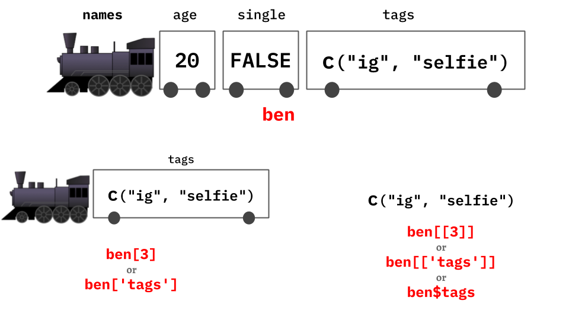

list as a train analogy

### Nested Structure

```r
a_lst <- list(name = "ben",
              info = list(age = 20,
                          tags = c("ig", "selfie")))

# Get "selfie"
a_lst[['info']]
a_lst[['info']][['tags']]
a_lst[['info']][['tags']][2]
```

```
#> $age
#> [1] 20
#>
#> $tags
#> [1] "ig"     "selfie"
#>
#> [1] "ig"     "selfie"
#> [1] "selfie"
```

```r
# Another way to get "selfie"
a_lst['info'][[1]]
a_lst['info'][[1]]['tags'][[1]]
a_lst['info'][[1]]['tags'][[1]][2]
```

```
#> $age
#> [1] 20
#>
#> $tags
#> [1] "ig"     "selfie"
#>
#> [1] "ig"     "selfie"
#> [1] "selfie"
```

```r
# Yet another way to get "selfie"
a_lst[[2]]
a_lst[[2]][[2]]
a_lst[[2]][[2]][2]
```

```
#> $age
#> [1] 20
#>
#> $tags
#> [1] "ig"     "selfie"
#>
#> [1] "ig"     "selfie"
#> [1] "selfie"
```

```r
# The most 'readable' way to get "selfie"
a_lst$info
a_lst$info$tags
a_lst$info$tags[2]
```

```
#> $age
#> [1] 20
#>
#> $tags
#> [1] "ig"     "selfie"
#>
#> [1] "ig"     "selfie"
#> [1] "selfie"
```

## for loop

- 上週介紹的條件式 (if-else) 讓我們可以依據不同狀況執行不同的程式碼，藉此能幫助我們寫出更有彈性的程式。迴圈讓我們能重複執行某一區塊的程式碼，如此就不需要重複寫出相同的程式碼。
- R 有 for 與 while 迴圈。一般而言，在資料分析時非常少會用到 while 迴圈，因此實習課不作介紹，有興趣的同學可自行參考線上教材或教科書。
- for loop 的結構如下

  ```r
  for (<變數> in <vector>) {
      <some code>
  }
  ```

- for loop 會使 `{}` 內的程式碼重複執行數次，其次數等於 `<vector>` 的長度；並且，在第 n 次開始執行 `{}` 內的程式碼前，會將 `<vector>` 裡的第 n 個元素指派給 `<變數>`。所以在第一次迴圈時，可透過 `<變數>` 取得 `<vector>` 中的第一個元素；在第二次迴圈時，可取得 `<vector>` 中的第二個元素；依此類推，最後一次迴圈則可以透過 `<變數>` 取得 `<vector>` 中的最後一個元素。

```r
vec <- c("謝", "老師", "好", "帥")

for (word in vec) {
    # Will execute 4 times,
    # each time a new value from `vec` will be assigned to `word`
    print(word)
}
```

```
#> [1] "謝"
#> [1] "老師"
#> [1] "好"
#> [1] "帥"
```

### for loop 的各種型態

- R 的 for 只有一種結構：每次疊代將 vector (或 list) 中的一個元素指派給變數 (`<var> in <vector>`)。但因為 R 向量式程式語言的特性，R 的 for 迴圈很容易改寫成其它更方便的型態。
1. 有時候我們需要知道**迴圈進行到 `<vector>` 的第幾個元素**，這時候通常會使用 `seq_along(<vector>)` 去製造出與 `<vector>` 等長的整數序列 (e.g. `seq_along(c('a', 'b', 'c'))` 會回傳 `1 2 3`)，如此我們便可知道進行到第幾次迴圈，也可透過 `<vector>[i]` 取得與該次迴圈對映的元素。

   ```r
   vec <- c("謝", "老師", "好", "帥")

   for (i in seq_along(vec)) {
       print(paste(i, vec[i]))
   }
   ```

   ```
   #> [1] "1 謝"
   #> [1] "2 老師"
   #> [1] "3 好"
   #> [1] "4 帥"
   ```

   ```r
   vec <- c("謝", "老師", "好", "帥")

   for (i in seq_along(vec)) {
       print(vec[i])

       # Print `?` in the last loop
       if (i == length(vec)) {
           print('?')
       }
   }
   ```

   ```
   #> [1] "謝"
   #> [1] "老師"
   #> [1] "好"
   #> [1] "帥"
   #> [1] "?"
   ```

2. 我們也可以透過 `names()` 在 for loop 裡使用 `<vector>` 的 names 屬性：

   ```r
   vec <- c(Monday = "rainy", Tuesday = "cloudy", Wednesday = "sunny")

   for (name in names(vec)) {
       print(paste0(name, ' was ', vec[name], '.'))
   }
   ```

   ```
   #> [1] "Monday was rainy."
   #> [1] "Tuesday was cloudy."
   #> [1] "Wednesday was sunny."
   ```

### `break` & `next`: 進階迴圈控制 (有興趣者自行參考)

- 有時候，我們需要對 for loop 有「更多的控制」。前面在 for loop 中使用到條件式即是一個例子。但常常條件式本身的功能並不足夠：執行迴圈時，在符合特定條件下，
  - 有時候我們會希望能**忽略一次迴圈中「所有尚未被執行的程式碼」**，這時就會使用到 `next`:

    ```r
    # 使用 next '忽略一次' 迴圈
    for (i in 1:10) {
        if (i == 5) {
            print("Skipping print(i) on line 194")
            next
        }
        print(i)
    }
    ```

    ```
    #> [1] 1
    #> [1] 2
    #> [1] 3
    #> [1] 4
    #> [1] "Skipping print(i) on line 194"
    #> [1] 6
    #> [1] 7
    #> [1] 8
    #> [1] 9
    #> [1] 10
    ```

  - 有時我們需要**跳出整個迴圈**，亦即不再執行 for loop 裡面的程式碼。這時就會使用到 `break`:

    ```r
    # 使用 break 跳出整個迴圈
    for (i in 1:10) {
        if (i == 5) {
            print("Breaking out the for loop")
            break
        }
        print(i)
    }
    ```

    ```
    #> [1] 1
    #> [1] 2
    #> [1] 3
    #> [1] 4
    #> [1] "Breaking out the for loop"
    ```

#### 實際應用：修改檔案名稱

下方的程式碼能將[上週作業](https://github.com/rlads2019/hw3)使用到的骰子的圖片重新命名 (並透過 `next` 忽略某些檔案)。有興趣者請下載[此週原始碼](https://rlads2019.github.io/lab/src/04.zip)，裡面有一個相同的資料夾 `dice/`，並且多出了一份檔案 `00_not_an_img.txt`，執行此程式碼前，需將**工作目錄設至 `dice/` 資料夾**。

```r
for (file in list.files()) {
    # 忽略 `00_not_an_img.txt` 這個檔案
    if (file == '00_not_an_img.txt') {
        next
    }

    file.rename(from = file,
                to = paste0('dice-', file))
}
```

## Wrap up：for loop 與 list

- [上週](https://rlads2019.github.io/lab/notes/03.html#wrap-up)我們使用過 3 個長度為 4 的 vector 來儲存關於 4 個人 (`kai`, `jessy`, `joy`, `ben`) 的資料。但使用這種方式儲存資料似乎有些違反直覺，因為它將關於一個人的資訊 (`name`, `age`, `about`) 分開來儲存在 3 個獨立的 vector。

  ```r
  # Data
  name <- c("kai", "jessy", "joy", "ben")
  age <- c(40, 20, 18, 19)
  about <- c("a professor", "a cat lover", "a hacker", "a YouTuber")
  ```

- 對於這種彼此之間具有關聯的資料，一種更好的方式是將它們**儲存在一起**，因為這不只幫助我們在「程式上」更容易去操弄這筆資料，更讓我們能以「階層組織」去「想像」我們的資料。這裡我們使用 `list` 去改寫上週的資料：

  ```r
  member <- list(
      kai = list(age = 40, about = "a professor"),
      jessy = list(age = 20, about = "a cat lover"),
      joy = list(age = 18, about = "a hacker"),
      ben = list(age = 19, about = "a YouTuber")
  )

  member
  ```

  ```
  #> $kai
  #> $kai$age
  #> [1] 40
  #>
  #> $kai$about
  #> [1] "a professor"
  #>
  #>
  #> $jessy
  #> $jessy$age
  #> [1] 20
  #>
  #> $jessy$about
  #> [1] "a cat lover"
  #>
  #>
  #> $joy
  #> $joy$age
  #> [1] 18
  #>
  #> $joy$about
  #> [1] "a hacker"
  #>
  #>
  #> $ben
  #> $ben$age
  #> [1] 19
  #>
  #> $ben$about
  #> [1] "a YouTuber"
  ```

  ```r
  for (name in names(member)) {
      someone <- member[[name]]

      # 將組成句子的片語儲存於 char vector `phrases`
      phrases <- c(name, someone$about, "is quite young.")
      if (someone$age > 35) {
          phrases[3] <- "should be wise."
      }

      # 在各片語之間插入逗點，形成一個句子
      sentence <- paste0(phrases,  collapse = ', ')

      print(sentence)
  }
  ```

  ```
  #> [1] "kai, a professor, should be wise."
  #> [1] "jessy, a cat lover, is quite young."
  #> [1] "joy, a hacker, is quite young."
  #> [1] "ben, a YouTuber, is quite young."
  ```

## data frame

- data frame 是 R 語言非常重要的資料結構，它造就了 R 強大的**表格式資料**處理能力
- data frame 是一種二維的資料結構。這種資料結構基本上與我們熟悉的 Excel (或 google 試算表) 非常類似：

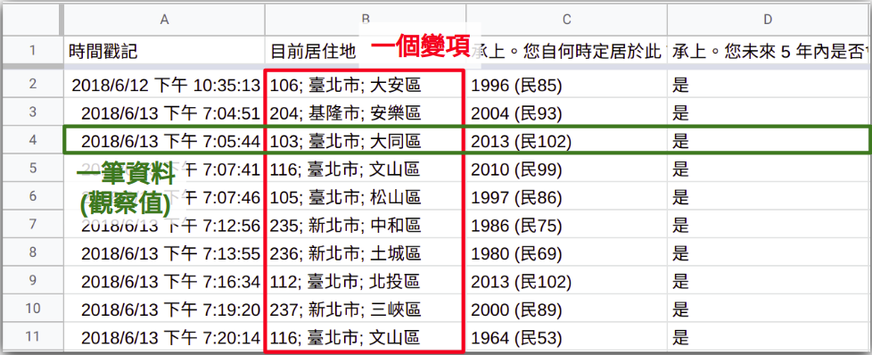

  - A data frame looks like an Excel Spreadsheet

  - data frame 的每一橫列 (row) 皆是一筆資料 (e.g. 一位受訪者所填的問卷)
  - data frame 的每一(直)欄 (column) 代表一個變項 (e.g. 問卷上的某個題目)

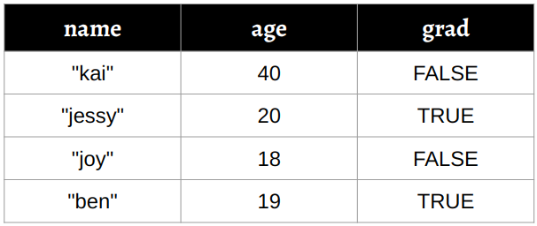

data frame 例子

- 我們可以使用 `tibble` 套件的 `tibble()`[^1] 建立 data frame。上圖中的 data frame 例子即可由下方的程式碼所建立:

  ```r
  library(tibble)

  df <- tibble(name = c("kai", "jessy", "joy", "ben"),
               age  = c(40, 20, 18, 19),
               grad = c(FALSE, TRUE, FALSE, TRUE))
  df
  ```

  ```
  #> # A tibble: 4 x 3
  #>   name    age grad
  #>   <chr> <dbl> <lgl>
  #> 1 kai      40 FALSE
  #> 2 jessy    20 TRUE
  #> 3 joy      18 FALSE
  #> 4 ben      19 TRUE
  ```

  - `tibble()` 裡的每個 vector 對映到 data frame 中的一欄 (column)。因此 data frame 中不同欄的資料類型可能不同，但**每一欄 (變項) 內的資料類型必須相同** (因為 vector 只能儲存相同的資料類型)。
- 下方的指令可用於檢視 data frame 的資訊

  ```r
  nrow(df)   # number of rows
  ```

  ```
  #> [1] 4
  ```

  ```r
  ncol(df)   # number of columns
  ```

  ```
  #> [1] 3
  ```

  ```r
  dim(df)    # 形狀 (num of rows, num of columns)
  ```

  ```
  #> [1] 4 3
  ```

  ```r
  names(df)  # name of each column
  ```

  ```
  #> [1] "name" "age"  "grad"
  ```

  ```r
  tibble::glimpse(df)  # 關於 df 的各種資訊
  ```

  ```
  #> Observations: 4
  #> Variables: 3
  #> $ name <chr> "kai", "jessy", "joy", "ben"
  #> $ age  <dbl> 40, 20, 18, 19
  #> $ grad <lgl> FALSE, TRUE, FALSE, TRUE
  ```

  ```r
  View(df)   # view df in RStudio source pane
  ```

### Subsetting: returning a data frame

- data frame 的篩選 (subsetting) 與 vector 和 list 類似，差別只在於 data frame 屬於二維的資料結構，因此需要提供 2 個 vector 進行資料的篩選：

  ```
  df[<vector 1>, <vector 2>]
  ```

  - 在這裡，`<vector 1>` 篩選的是「列 (row)」，亦即，`<vector 1>` 決定要篩選出哪幾個觀察值 (observations)。`<vector 2>` 篩選的則是「欄 (column)」，亦即，`<vector 2>` 決定要篩選出哪些變項 (variables)。
  - 以這種語法進行篩選，回傳的**一定是 data frame**[^2]，即使只有篩選出一個值 (e.g. df[1, 1])

```r
df[2, 1]
```

```
#> # A tibble: 1 x 1
#>   name
#>   <chr>
#> 1 jessy
```

```r
df[2, 1:2]  # df[2, c("name", "age")]
```

```
#> # A tibble: 1 x 2
#>   name    age
#>   <chr> <dbl>
#> 1 jessy    20
```

```r
df[2, ]
```

```
#> # A tibble: 1 x 3
#>   name    age grad
#>   <chr> <dbl> <lgl>
#> 1 jessy    20 TRUE
```

### Subsetting: returning a vector

- 若想要從 data frame 裡面篩選出 vector (取得「火車車廂」**內**的值)，則要使用前面提過的 `$` 或 `[[]]`:

  ```
  df[["<column_name>"]]
  df[[<column_index>]]
  df$<column_name>
  ```

  ```r
  df[[2]]
  df[["age"]]
  df$age  # 最常見
  ```

  ```
  #> [1] 40 20 18 19
  #> [1] 40 20 18 19
  #> [1] 40 20 18 19
  ```

- 篩選 data frame 而回傳 vector 是個很實用的技巧，因為我們可以使用這個回傳的 vector 當作我們進一步篩選 data frame 的依據，例如：

  ```r
  over19 <- df$age > 19
  over19
  ```

  ```
  #> [1]  TRUE  TRUE FALSE FALSE
  ```

  ```r
  # subset df with obs. over 19
  df[over19, ]
  ```

  ```
  #> # A tibble: 2 x 3
  #>   name    age grad
  #>   <chr> <dbl> <lgl>
  #> 1 kai      40 FALSE
  #> 2 jessy    20 TRUE
  ```

  ```r
  # subset df with obs. below or equal 19
  df[!over19, ]
  ```

  ```
  #> # A tibble: 2 x 3
  #>   name    age grad
  #>   <chr> <dbl> <lgl>
  #> 1 joy      18 FALSE
  #> 2 ben      19 TRUE
  ```

  ```r
  # 合併起來寫 (最常見的寫法，但比較難讀懂)
  df[df$age > 19, ]
  ```

  ```
  #> # A tibble: 2 x 3
  #>   name    age grad
  #>   <chr> <dbl> <lgl>
  #> 1 kai      40 FALSE
  #> 2 jessy    20 TRUE
  ```

- 透過這個技巧，R 能幫助我們快速篩選出需要的資料，例如，我們可以結合 `age` 與 `grad` 兩個變項，篩選出「小於 20 歲且為研究所學生」的 data frame:

  ```r
  df[(df$age < 20) & (df$grad), ]
  ```

  ```
  #> # A tibble: 1 x 3
  #>   name    age grad
  #>   <chr> <dbl> <lgl>
  #> 1 ben      19 TRUE
  ```

[^1]: R 的內建函數 `data.frame()` 是最常被用於建立 data frame 的函數。`tibble` 套件裡的 `tibble()` 則與 `data.frame()` 的功能幾乎一樣，只是 `tibble()` 更改了 `data.frame()` 裡面常令使用者感到困惑的一些預設行為。

    `tibble` 套件為 [Tidyverse](https://www.tidyverse.org) 套件群的一員，目的是為了解決 base R 眾多函數紛亂不一致的問題 (e.g. 命名不一致、預設行為不一致、類似的函數回傳值不一致等)。
[^2]: 這只有使用 `tibble` 套件的 `tibble()` 所回傳的 data frame (class 為 `tbl_df`, `tbl` 與 `data.frame`) 才有這種特性。使用 R 的內建函數 `data.frame()` 所建立的 data frame 或是 R 的內建資料集 (class 只有 `data.frame`) 則會根據所篩選出之資料的形狀的不同而回傳不同的資料結構 (有可能是 `data.frame` 或是 `vector`)